# Tutorial 05 - Bayesian Regression

Ryan Mitchell

28 March, 2023

## Topics

- Get a brief introduction to Bayesian statistics and understand how it differs from the frequentist point of view.
- Understand the difference between a credible interval and a confidence interval, particularly in how they can be interpreted.
- Understand how to create a Bayesian simple linear regression model with the `brms` package using different priors.
- Understand how to create a Bayesian multivariate linear regression model with the `brms` package using different priors.

## Installations and Data

This tutorial will make use of the following R libraries.

```r
library(brms)
library(patchwork)
library(pander)
library(broom.mixed)
library(tidyverse)
library(bayesplot)
```

This tutorial will be using the `nhanes` dataset where the variables are described in the file `nhanes-codebook.txt`. This data can be loaded with the `load` function, specifying the rda data file.

```r
load(file = 'nhanes1518.rda')
```

## Introduction to Bayesian Statistics

### Beliefs and Priors

There are two schools of thought in the world of statistics: frequentist, which we have been working with up to this point, and Bayesian. In the frequentist school, probability is defined as a frequency. For example, if we roll a fair six-sided die, the probability we will roll a 1 is $P(Y = 1) = \frac{1}{6}$. The conclusions we make in frequentist statistics are based on likelihood; we retrieve data and then make an inference based on the data.

In the Bayesian school, probability is defined as a belief. For example, a Bayesian statement could be “I believe the probability that it rains tomorrow is 30%.” Different people obviously have different beliefs, so another statistician stating “I believe the probability that it rains tomorrow is 40%” is just as valid. Like frequentist statistics, our conclusions rely on likelihood. However, unlike frequentist statistics, our conclusions combine the likelihood with another factor: our prior knowledge. When we collect data, we then combine our prior knowledge and our likelihood to *update* our prior knowledge. For simplicity, we can simply refer to our prior knowledge that we wish to update as the **prior**. After we see our data, we combine our likelihood with our prior to create the **posterior**.

It is important to understand that different statisticians can have different priors for the same data. For example, a statistician who lives in the desert may believe that the probability that it rains tomorrow is 5%. However, if they move to the rainforest, their belief on future rain chances will change dramatically. This example analogizes how we combine our prior knowledge (living in the desert leads to a low chance for rain) with our data (the amount of rain after we move to the rainforest) to obtain our posterior (living in the rainforest leads to a high chance for rain).

A statistician can also have no prior knowledge. Suppose, unrealistically, that a statistician has no idea how likely it is to rain on any given day. When that statistician is asked for the probability that it will rain tomorrow, they have no beliefs to go off of. This statistician can then use an **uninformative prior**, or one that tells us little about the situation at hand, to describe rain chances. A common example of an uninformative prior is a $Uniform(0, 1)$ distribution, which would mean the probability that it rains tomorrow has an equal chance of being any value from 0 to 1.

But how exactly do we get from the prior and the likelihood to the posterior?

### Bayes’ Rule

The fundamental concept of Bayesian statistics is the fittingly-named **Bayes’ rule**. Given a **likelihood function** $p(y | \theta)$ and a prior $p(\theta)$, the posterior $p(\theta | y)$ stated by Bayes’ rule is $p(\theta | y) = \frac{p(y | \theta)p(\theta)}{p(y)}$.

For example, we can use the Bayes’ rule with our `nhanes` dataset to estimate the proportion of subjects in the dataset with a concentration of Mono(carboxynonyl) phthalate above 10 ng/mL that are female. For simplicity, we will only consider subjects with data points present for both the `RIAGENDR` variable, which deals with gender.

```r
bayesrule_ex <- nhanes1518 %>%
  filter(!is.na(RIAGENDR) & URXCNP > 10)
```

In this example, $\theta$ is the parameter we are interested in (the proportion of subjects in this subsetted dataset that are female). $y$ is our data, or `bayesrule_ex`. Let’s assume we have no prior knowledge on whether men or women are more likely to have high Mono(carboxynonyl) phthalate concentrations. Thus, we would set our prior at 0.5 (we believe that it is equally likely for men and women to have concentrations above 10 ng/mL). In a complete Bayesian analysis, we would then combine this with our data (in which the proportion is 0.467) to obtain a posterior. It is important to note that the posterior we will obtain will not be the same as, for example, the posterior we would obtain if we chose a prior of 0.9. People with different priors will have different posteriors.

Note that this is an extremely simplified example. Here, we use a point estimate for our prior (0.5), but usually our prior comes from a probability distribution. For example, again assuming we have no prior knowledge, one prior we could choose is a $Uniform(0, 1)$ distribution. This stipulates that we believe the true proportion has an equal chance of being any value between 0 and 1.

### Posteriors

Just like how our priors usually come from probability distributions, so do our posteriors. This is a key distinction from frequentist statistics, where $\theta$ is a fixed value. In Bayesian statistics, $\theta$ is a **random variable**, or a quantity that can take on different values based on different outcomes of an experiment. For example, if our posterior for $\theta$ is a $Uniform(0, 1)$ distribution, then $\theta$ will take on an array of different values from 0 to 1 if we repeatedly sampled from this distribution. The fixed-value estimate for $\theta$ in frequentist statistics usually maps to the mean of this posterior distribution in Bayesian statistics (which, in the case of a $Uniform(0, 1)$ distribution is 0.5).

When conducting hypothesis tests or linear regressions using the frequentist approach, we often find it useful to create a **confidence interval** for $\theta$. Confidence intervals help us estimate the (un)certainty of a parameter with a lower and upper bound. For example, let’s say we create a 95% confidence interval for $\theta =$ the mean age in our datase; we find the lower bound to be 32 and the upper bound to be 47. We could then interpret this confidence interval as “We are 95% confident that the true mean age is between 32 and 47 years old.” If we constructed many more similar confidence intervals, we would expect 95% of them to contain the true population mean.

The Bayesian equivalent to a confidence interval is known as a **credible interval**, which has a simpler interpretation. For example, a 95% credible interval is between any lower bound $L$ and any upper bound $U$ such that the posterior probability of $L < p < U = 0.95$. We use the quantiles of the posterior distribution for $\theta$ to obtain $L$ and $U$. In the case of a 95% interval, these are the 0.025 and 0.975 quantiles (the middle 95% of the data). If we find the 95% credible interval for the mean age in our dataset to have a lower bound of 32 and an upper bound of 47, then we can simply say that “There is a 95% probability that the true mean age is between 32 and 47 years old.”

## Bayesian Simple Linear Regression

### Notation, Parameters, and Assumptions

In statistics, we use **linear regression** to model the relationship between a **response variable** and one or more **explanatory variables**. Linear regression is done differently in frequentist statistics and Bayesian statistics.

In **simple linear regression**, we have one explanatory variable. Simple linear regression takes the form $y = \beta_0 +\beta_1 x +\epsilon$, where $y$ is the response variable, $x$ is the explanatory variable, $\beta_1$ is the true slope of the relationship between $x$ and $y$, $\beta_0$ is the true intercept of the relationship between $x$ and $y$, and $\epsilon$ is the random error term.

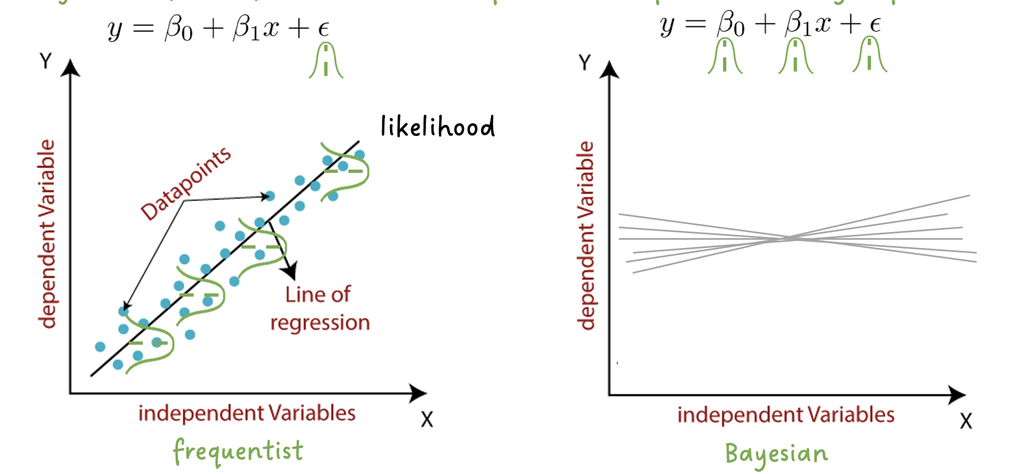

In frequentist statistics, linear regression uses point estimates for parameters $\beta_0$ and $\beta_1$ in order to help predict the value of the response variable based on the explanatory variable. The formula for **Bayesian regression** may appear to be the same, but now, our parameters are drawn from probability distributions. If we have a vague prior, we will have weak correlations between the independent and dependent variables. This explains the lack of steepness in the lines on the Bayesian graph in the visualization above. After we see the data and update our prior, we will begin to see stronger correlations between the variables.

The assumptions for Bayesian linear regression are the same for the frequentist method, being as follows:

- **linearity**: The relationship between the response and explanatory variables is linear.
- **independence**: The observations are independent of each other, meaning that the results for one observation are not influenced by the results of any other observation.
- **homoscedasticity**: The variance of the errors is constant for all values of the explanatory variables.
- **normality**: The errors are normally distributed.
- **no multicollinearity**: The explanatory variables are not highly correlated with each other.
- **no autocorrelation**: The errors are not correlated with each other.

It is important that these assumptions are not violated to preserve the validity of the regression model. Later, we will learn how to verify that our model fits these assumptions.

### Motivation

As discussed earlier, we perform simple linear regression when we want to explore the relationship between one explanatory variable and one response variable. For example, we might want to better understand the relationship between body mass index and age for a variety of reasons–perhaps we want to know if different age groups are more prone to obesity. We can help answer this question with a simple linear regression model using the `nhanes` dataset.

For this linear model, we want to predict body mass index based on age; therefore, we will use `BMXBMI` as our response variable and `RIDAGEYR` as our explanatory variable. We will limit our analysis to adults.

```r
nhanes1518 <- nhanes1518 %>%
  filter(RIDAGEYR >= 18)
```

### Model

We will use the `brms` library to create our Bayesian model. An important part of creating a Bayesian regression model is establishing our priors for the parameters. Based on our prior knowledge of the data, there is a variety of priors we can set (and thus a variety of models we can create). Later, we will discuss strategies for selecting model priors. For now, we will assume that we have no prior knowledge of the dataset, using a noninformative prior (the default prior in `brms`). We can use the `brm` function to create our model. The `formula` argument of this function follows the format `y ~ x`, with `y` being the response variable and `x` being the explanatory variable. We will save our model in a variable named `model1`.

```r
model1 <- brm(formula = BMXBMI ~ RIDAGEYR,
             data    = nhanes1518,
             seed    = 123)
```

### Interpretation

Once we have created our model, we will then interpret its results. Our model gives us posterior distributions for $\beta_{Intercept}$ and $\beta_{Age}$; we can plot these with the `mcmc_dens` function of the `bayesplot` package, specifying the distributions we want to plot with the `pars` argument.

We can also use the `summary` function to view more detailed statistics of our model. We will set the `priors` argument to `TRUE` so that the summary includes the prior distributions we used for our model.

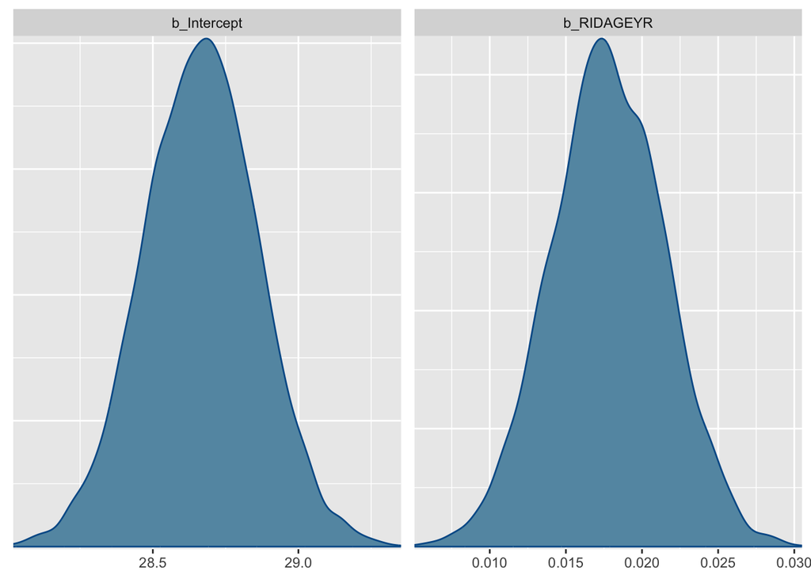

```r
mcmc_dens(model1, pars = c("b_Intercept", "b_RIDAGEYR"))
```

```r
summary(model1, priors = TRUE)
```

```
##  Family: gaussian
##   Links: mu = identity; sigma = identity
## Formula: BMXBMI ~ RIDAGEYR
##    Data: nhanes1518 (Number of observations: 11096)
##   Draws: 4 chains, each with iter = 2000; warmup = 1000; thin = 1;
##          total post-warmup draws = 4000
##
## Priors:
## Intercept ~ student_t(3, 28.4, 6.4)
## <lower=0> sigma ~ student_t(3, 0, 6.4)
##
## Population-Level Effects:
##           Estimate Est.Error l-95% CI u-95% CI Rhat Bulk_ESS Tail_ESS
## Intercept    28.66      0.20    28.28    29.04 1.00     4763     3278
## RIDAGEYR      0.02      0.00     0.01     0.03 1.00     5132     3187
##
## Family Specific Parameters:
##       Estimate Est.Error l-95% CI u-95% CI Rhat Bulk_ESS Tail_ESS
## sigma     7.26      0.05     7.17     7.36 1.00     3864     3165
##
## Draws were sampled using sampling(NUTS). For each parameter, Bulk_ESS
## and Tail_ESS are effective sample size measures, and Rhat is the potential
## scale reduction factor on split chains (at convergence, Rhat = 1).
```

$$\hat{BMI} = 28.66 +
0.02(Age)$$

We can interpret the estimate of the slope to mean that for every 1 year increase in age, we expect BMI to increase by 0.02 on average. The intercept does not have a meaningful interpretation in this case as it assumes a person with an age of 0, which is unrealistic.

### Inference

We are also interested in the `l-95% CI` and `u-95% CI` columns of the `summary` output. These estimates are obtained from the credible intervals of the posterior distributions we plotted with `mcmc_dens`. We can thus state that there is a 95% chance that the true value for the intercept lies between 28.28 and 29.04, and there is a 95% chance that the true value for $\beta_{Age}$ lies between 0.01 and 0.03.

Now that we have a confidence interval for our slope, we might want to conclude whether there is a statistically significant relationship between BMI and age To do so, we can examine whether or not $\hat{\beta_{Age}}$ is statistically different from 0. Our **null hypothesis** in this case is that the slope is equal to 0, while our **alternative hypothesis** is that the slope is not equal to 0 (which implies a linear relationship between BMI and age). We can answer this question with our credible interval. Since the interval for `RIDAGEYR` does not include 0, we can reject our null hypothesis and conclude that there is likely a linear relationship between age and body mass index (although it appears to be very small).

### Prediction

Suppose we want to guess an individual’s BMI using our model. We can do this with a **prediction interval**; it differs from using normal confidence intervals as confidence intervals only express sampling uncertainty from our data. On the other hand, prediction intervals express sampling uncertainty from our data and from the single value with which we want to predict. As a result, prediction intervals are wider than confidence intervals.

We can use the `predict` function with our model to predict individual’s BMIs given an age of 20, 40, and 60.

```r
set.seed(123)
predict(model1,
        data.frame(RIDAGEYR = (c(20, 40, 60))),
        interval = "prediction") %>%
  knitr::kable(digits = 2)
```

| Estimate | Est.Error | Q2.5 | Q97.5 |
| --- | --- | --- | --- |
| 29.07 | 7.21 | 14.73 | 43.29 |
| 29.33 | 7.24 | 15.05 | 43.08 |
| 29.77 | 7.30 | 15.33 | 44.06 |

Our prediction interval estimates that a 20-year-old individual likely has a BMI between 14.73 and 43.29. As we can see, the interval is extremely wide, limiting our ability to make meaningful conclusions; this is likely because the relationship between BMI and age is weak.

## Bayesian Multivariate Linear Regression

### Motivation

Now that we’ve tackled simple linear regression, let’s learn how to do **multivariate linear regression** the Bayesian way. We do multivariate regression when we want to know how one variable is impacted by multiple other variables. We can also use this method when we want to control for some variable. For example, in our `nhanes` dataset, we might want to know how factors like age, waist size, weight, and height impact BMI; we might also want to know how waist size, weight, and height impact BMI if we control for age. To help answer these questions, we can fit a model with `BMXBMI` as the response and `RIDAGEYR`, `BMXWAIST`, `BMXWT`, and `BMXHT` as the predictors.

### Model

Let’s first visualize the distribution of all of our predictor variables in the dataset.

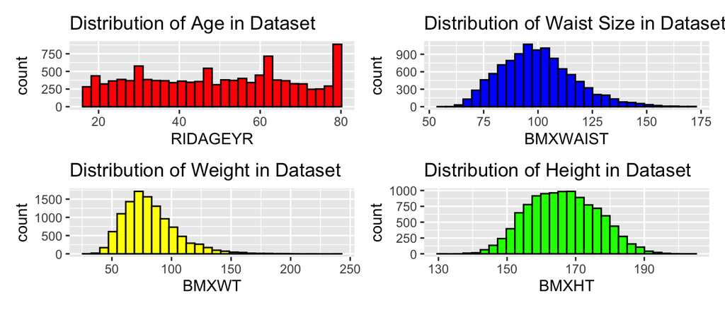

```r
p1 <- ggplot(nhanes1518, aes(x = RIDAGEYR)) +
  geom_histogram(color = "black", fill = "red") +
  labs(title = 'Distribution of Age in Dataset')

p2 <- ggplot(nhanes1518, aes(x = BMXWAIST)) +
  geom_histogram(color = "black", fill = "blue") +
  labs(title = 'Distribution of Waist Size in Dataset')

p3 <- ggplot(nhanes1518, aes(x = BMXWT)) +
  geom_histogram(color = "black", fill = "yellow") +
  labs(title = 'Distribution of Weight in Dataset')

p4 <- ggplot(nhanes1518, aes(x = BMXHT)) +
  geom_histogram(color = "black", fill = "green") +
  labs(title = 'Distribution of Height in Dataset')

p1 + p2 + p3 + p4 +
  plot_layout(ncol = 2)
```

```r
nhanes1518['RIDAGEYR_sc'] <- scale(nhanes1518$RIDAGEYR)
nhanes1518['BMXWAIST_sc'] <- scale(nhanes1518$BMXWAIST)
nhanes1518['BMXWT_sc'] <- scale(nhanes1518$BMXWT)
nhanes1518['BMXHT_sc'] <- scale(nhanes1518$BMXHT)
```

Again, we will begin by assuming we have no prior knowledge of the data and use the default the prior in `brms`. We will again use the `brm` function to create our model. The format for the `formula` argument here is `y ~ x1 + x2 + .. + xn`, where each $x_i$ is an explanatory variable.

```r
multi_model1 <- brm(formula = BMXBMI ~ RIDAGEYR_sc + BMXWAIST_sc + BMXHT_sc + BMXWT_sc,
             data    = nhanes1518,
             seed    = 123)
```

### Interpretation

We can once again interpret our model’s results with the `summary` function.

```r
summary(multi_model1, priors = TRUE)
```

```
##  Family: gaussian
##   Links: mu = identity; sigma = identity
## Formula: BMXBMI ~ RIDAGEYR_sc + BMXWAIST_sc + BMXHT_sc + BMXWT_sc
##    Data: nhanes1518 (Number of observations: 10534)
##   Draws: 4 chains, each with iter = 2000; warmup = 1000; thin = 1;
##          total post-warmup draws = 4000
##
## Priors:
## Intercept ~ student_t(3, 28.3, 6.4)
## <lower=0> sigma ~ student_t(3, 0, 6.4)
##
## Population-Level Effects:
##             Estimate Est.Error l-95% CI u-95% CI Rhat Bulk_ESS Tail_ESS
## Intercept      29.53      0.01    29.51    29.54 1.00     4105     2265
## RIDAGEYR_sc    -0.07      0.01    -0.09    -0.06 1.00     2659     2529
## BMXWAIST_sc     0.28      0.03     0.23     0.34 1.00     1692     1922
## BMXHT_sc       -3.49      0.01    -3.51    -3.47 1.00     2127     2551
## BMXWT_sc        7.70      0.03     7.65     7.76 1.00     1627     1881
##
## Family Specific Parameters:
##       Estimate Est.Error l-95% CI u-95% CI Rhat Bulk_ESS Tail_ESS
## sigma     0.84      0.01     0.83     0.85 1.00     4902     2819
##
## Draws were sampled using sampling(NUTS). For each parameter, Bulk_ESS
## and Tail_ESS are effective sample size measures, and Rhat is the potential
## scale reduction factor on split chains (at convergence, Rhat = 1).
```

With these statistics, we can now fill in our model:

$$\hat{BMI} = 29.53 - 0.07(Age\_sc) +
0.28(Waist\_sc) - 3.49(Height\_sc) + 7.70(Weight\_sc)$$

We can see that the $\hat{\beta_{Height}}$ and $\hat{\beta_{Weight}}$ are the largest in magnitude, meaning they have the most impact on BMI. This makes intuitive sense, as BMI is calculated from height and weight.

### Inference

We can again look at the `l-95% CI` and `u-95% CI` columns to obtain 95% credible intervals for our intercept and estimates. Since all of the intervals do not include 0, we can reject our null hypothesis for all variables and conclude that, holding all other factors constant, there is likely a linear relationship between height and BMI, weight and BMI, age and BMI, and waist size and BMI.

## Prior Selection

### Introduction

So far in this tutorial, we have used the default priors for our linear regression models. However, one of the foundations of Bayesian statistics is setting an informative prior, or one that tells us something about the data.

Prior selection is especially important when we do not have a lot of data. In these cases, since there is not much data to go off of, much of our inference comes from the prior. This means it is vital that we select a fitting distribution, or we risk an inaccurate posterior.

There are many different types of priors we can choose from, and they prove handy in different cases. This section will discuss common priors used for coefficients ($\beta$) and variances ($\sigma^2$).

Since we have thousands of observations in our dataset, the different priors we may set would yield similar results. To better demonstrate how choosing different priors can impact our model, let’s take a sample of our dataset of size `n = 30`.

```r
set.seed(456)
nhanes1518_sample <- sample_n(nhanes1518, 30)
```

Now, using our sampled data, let’s see the results of a model using default priors.

```r
default_prior <- brm(formula = BMXBMI ~ RIDAGEYR,
             data    = nhanes1518_sample,
             seed    = 123)
```

```r
summary(default_prior, priors = TRUE)
```

```
##  Family: gaussian
##   Links: mu = identity; sigma = identity
## Formula: BMXBMI ~ RIDAGEYR
##    Data: nhanes1518_sample (Number of observations: 26)
##   Draws: 4 chains, each with iter = 2000; warmup = 1000; thin = 1;
##          total post-warmup draws = 4000
##
## Priors:
## Intercept ~ student_t(3, 27.5, 5.5)
## <lower=0> sigma ~ student_t(3, 0, 5.5)
##
## Population-Level Effects:
##           Estimate Est.Error l-95% CI u-95% CI Rhat Bulk_ESS Tail_ESS
## Intercept    36.19      5.43    25.57    47.06 1.00     3558     2810
## RIDAGEYR     -0.12      0.10    -0.31     0.07 1.00     3421     2435
##
## Family Specific Parameters:
##       Estimate Est.Error l-95% CI u-95% CI Rhat Bulk_ESS Tail_ESS
## sigma     9.40      1.35     7.19    12.51 1.00     3767     2878
##
## Draws were sampled using sampling(NUTS). For each parameter, Bulk_ESS
## and Tail_ESS are effective sample size measures, and Rhat is the potential
## scale reduction factor on split chains (at convergence, Rhat = 1).
```

We get the model $\hat{BMI} = 36.19 - 0.12(Age)$. We will compare this to models using specified priors.

### Coefficient Priors: The Normal Distribution

A common prior for the coefficient (or $\beta$) in Bayesian inference deals with a **normal (Gaussian) distribution**. This is a **conjugate** prior, meaning that the posterior will also be a normal distribution, but with different parameters. This might be a good choice for our beta prior if we assume our data is normally distributed, meaning most values are situated in the middle, and there is a symmetrical decline in the frequency of values as we reach the ends.

We will use the same `BMXBMI ~ RIDAGEYR` model we worked with in the single linear regression section. Let’s assume the BMI values in our sample are normally distributed. We will choose a normal distribution with $\mu = 0$ and $\sigma = 0.3$ for $\beta_{Age}$. We can use the `prior` argument in the `brm` function to set our prior for $\beta$. In this argument, we set `class = "b"` and `coef = "RIDAGEYR"` to signify that this is a prior on $\beta_{Age}$.

```r
model2 <- brm(formula = BMXBMI ~ RIDAGEYR,
             data    = nhanes1518_sample,
             prior   = c(set_prior("normal(0, 0.3)", class = "b", coef = "RIDAGEYR")),
             seed    = 123)
```

```r
summary(model2, priors = TRUE)
```

```
##  Family: gaussian
##   Links: mu = identity; sigma = identity
## Formula: BMXBMI ~ RIDAGEYR
##    Data: nhanes1518_sample (Number of observations: 26)
##   Draws: 4 chains, each with iter = 2000; warmup = 1000; thin = 1;
##          total post-warmup draws = 4000
##
## Priors:
## b_RIDAGEYR ~ normal(0, 0.3)
## Intercept ~ student_t(3, 27.5, 5.5)
## <lower=0> sigma ~ student_t(3, 0, 5.5)
##
## Population-Level Effects:
##           Estimate Est.Error l-95% CI u-95% CI Rhat Bulk_ESS Tail_ESS
## Intercept    35.77      5.38    25.20    46.15 1.00     3583     2673
## RIDAGEYR     -0.11      0.09    -0.29     0.08 1.00     3460     2563
##
## Family Specific Parameters:
##       Estimate Est.Error l-95% CI u-95% CI Rhat Bulk_ESS Tail_ESS
## sigma     9.41      1.37     7.16    12.63 1.00     3407     2799
##
## Draws were sampled using sampling(NUTS). For each parameter, Bulk_ESS
## and Tail_ESS are effective sample size measures, and Rhat is the potential
## scale reduction factor on split chains (at convergence, Rhat = 1).
```

As we see from the summary, the estimates for the intercept and $\beta_{Age}$ differ slightly from our default model, demonstrating how different priors can yield different results.

Let’s run another model with a normally distributed $\beta$ prior, using the same mean but inputting a much larger variance.

```r
model3 <- brm(formula = BMXBMI ~ RIDAGEYR,
             data    = nhanes1518_sample,
             prior   = c(set_prior("normal(0, 100)", class = "b", coef = "RIDAGEYR")),
             seed    = 123)
```

```r
summary(model3, priors = TRUE)
```

```
##  Family: gaussian
##   Links: mu = identity; sigma = identity
## Formula: BMXBMI ~ RIDAGEYR
##    Data: nhanes1518_sample (Number of observations: 26)
##   Draws: 4 chains, each with iter = 2000; warmup = 1000; thin = 1;
##          total post-warmup draws = 4000
##
## Priors:
## b_RIDAGEYR ~ normal(0, 100)
## Intercept ~ student_t(3, 27.5, 5.5)
## <lower=0> sigma ~ student_t(3, 0, 5.5)
##
## Population-Level Effects:
##           Estimate Est.Error l-95% CI u-95% CI Rhat Bulk_ESS Tail_ESS
## Intercept    36.23      5.41    25.85    47.00 1.00     3371     2549
## RIDAGEYR     -0.12      0.10    -0.31     0.06 1.00     3404     2489
##
## Family Specific Parameters:
##       Estimate Est.Error l-95% CI u-95% CI Rhat Bulk_ESS Tail_ESS
## sigma     9.37      1.34     7.15    12.37 1.00     3173     2984
##
## Draws were sampled using sampling(NUTS). For each parameter, Bulk_ESS
## and Tail_ESS are effective sample size measures, and Rhat is the potential
## scale reduction factor on split chains (at convergence, Rhat = 1).
```

Let’s recap the models we’ve created so far with their results:

| $\beta_{Age}$ Distributions | Posterior Means | Intercepts |
| --- | --- | --- |
| Default | -0.12 | 36.19 |
| N(0, 0.09) | -0.11 | 35.77 |
| N(0, 10000) | -0.12 | 36.23 |

### Coefficient Priors: The T-Distribution

Another common prior for the coefficient in Bayesian inference deals with the **student t-distribution**. This differs from the normal distribution in that the values are less clustered in the middle, giving it heavier tails on the ends. Using the t-distribution can offer more robust estimation; it is often used on smaller, approximately normal datasets (for example, when n < 30). For the purpose of this section, we will proceed using a t-distribution to estimate $\beta_{Age}$.

We can change the shape of our t-distribution by altering the **degrees of freedom**; the more degrees of freedom we have, the more we will resemble a normal distribution (so, the less heavy the tail ends will be). Let’s fit a model with a beta prior distributed as a unit t-distribution with 3 degrees of freedom:

```r
model4 <- brm(formula = BMXBMI ~ RIDAGEYR,
             data    = nhanes1518_sample,
             prior   = c(set_prior("student_t(3, 0, 1)", class = "b", coef = "RIDAGEYR")),
             seed    = 123)
```

```r
summary(model4, priors = TRUE)
```

```
##  Family: gaussian
##   Links: mu = identity; sigma = identity
## Formula: BMXBMI ~ RIDAGEYR
##    Data: nhanes1518_sample (Number of observations: 26)
##   Draws: 4 chains, each with iter = 2000; warmup = 1000; thin = 1;
##          total post-warmup draws = 4000
##
## Priors:
## b_RIDAGEYR ~ student_t(3, 0, 1)
## Intercept ~ student_t(3, 27.5, 5.5)
## <lower=0> sigma ~ student_t(3, 0, 5.5)
##
## Population-Level Effects:
##           Estimate Est.Error l-95% CI u-95% CI Rhat Bulk_ESS Tail_ESS
## Intercept    36.18      5.34    25.64    47.04 1.00     3039     2387
## RIDAGEYR     -0.12      0.09    -0.30     0.07 1.00     3095     2246
##
## Family Specific Parameters:
##       Estimate Est.Error l-95% CI u-95% CI Rhat Bulk_ESS Tail_ESS
## sigma     9.40      1.39     7.20    12.57 1.00     2842     2515
##
## Draws were sampled using sampling(NUTS). For each parameter, Bulk_ESS
## and Tail_ESS are effective sample size measures, and Rhat is the potential
## scale reduction factor on split chains (at convergence, Rhat = 1).
```

Again, our model results resemble those we have previously calculated. For demonstrative purposes, let’s also run a model with more degrees of freedom (a more Gaussian-like distribution).

```r
model5 <- brm(formula = BMXBMI ~ RIDAGEYR,
             data    = nhanes1518_sample,
             prior   = c(set_prior("student_t(10000, 0, 1)", class = "b", coef = "RIDAGEYR")),
             seed    = 123)
```

```r
summary(model5, priors = TRUE)
```

```
##  Family: gaussian
##   Links: mu = identity; sigma = identity
## Formula: BMXBMI ~ RIDAGEYR
##    Data: nhanes1518_sample (Number of observations: 26)
##   Draws: 4 chains, each with iter = 2000; warmup = 1000; thin = 1;
##          total post-warmup draws = 4000
##
## Priors:
## b_RIDAGEYR ~ student_t(10000, 0, 1)
## Intercept ~ student_t(3, 27.5, 5.5)
## <lower=0> sigma ~ student_t(3, 0, 5.5)
##
## Population-Level Effects:
##           Estimate Est.Error l-95% CI u-95% CI Rhat Bulk_ESS Tail_ESS
## Intercept    36.27      5.38    25.20    46.87 1.00     3425     2661
## RIDAGEYR     -0.12      0.10    -0.31     0.07 1.00     3301     2414
##
## Family Specific Parameters:
##       Estimate Est.Error l-95% CI u-95% CI Rhat Bulk_ESS Tail_ESS
## sigma     9.42      1.36     7.21    12.49 1.00     3440     2860
##
## Draws were sampled using sampling(NUTS). For each parameter, Bulk_ESS
## and Tail_ESS are effective sample size measures, and Rhat is the potential
## scale reduction factor on split chains (at convergence, Rhat = 1).
```

And now let’s once again recap our models:

| $\beta_{Age}$ Distributions | Posterior Means | Intercepts |
| --- | --- | --- |
| Default | -0.12 | 36.19 |
| N(0, 0.09) | -0.11 | 35.77 |
| N(0, 10000) | -0.12 | 36.23 |
| StudentT(3, 0, 1) | -0.12 | 36.18 |
| StudentT(10000, 0, 1) | -0.12 | 36.27 |

Upon selecting our priors and running our models, we can then use our posterior information to conduct further regression. Usually, regardless of the initial choice of prior, results will end up converging to the same posterior after many iterations. In this case, since our sample size is now very small (`n = 30`), it might be more intelligent to start with a student-t distribution for our $\beta_{Age}$ parameter.

### Variance Priors: The Inverse-Gamma

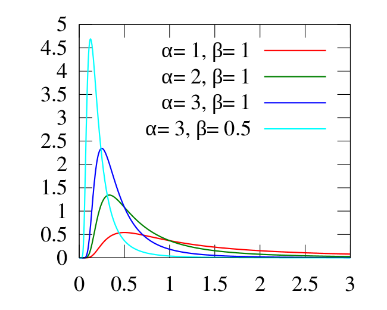

Now let’s move on to our variance (or $\sigma^2$) parameter. A common prior for the variance in Bayesian inference deals with the **inverse gamma distribution**. This particular distribution restricts the variance to only positive values (we cannot have a negative variance as it is the value of the standard deviation squared). The inverse gamma distribution takes two parameters, $\alpha$ and $\beta$, which impact the shape (different permutations of these parameters are pictured above). It is also a conjugate distribution, so our posterior will be an inverse gamma distribution.

Let’s run two models with inverse-gamma variance priors, using the parameters of the light blue line and the red line in the visualization above. We will use our `nhanes1518_sample` dataset that we created in the previous section.

```r
model6 <- brm(formula = BMXBMI ~ RIDAGEYR,
             data    = nhanes1518_sample,
             prior   = c(set_prior("inv_gamma(3, 0.5)", class = "sigma")),
             seed    = 123)
```

```r
model7 <- brm(formula = BMXBMI ~ RIDAGEYR,
             data    = nhanes1518_sample,
             prior   = c(set_prior("inv_gamma(1, 1)", class = "sigma")),
             seed    = 123)
```

### Variance Priors: The Half-Cauchy Distribution

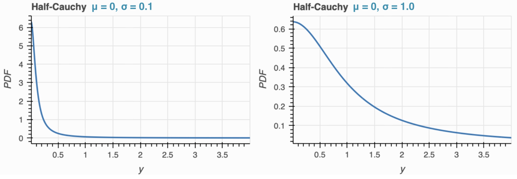

Another common prior for the variance in Bayesian inference deals with the **Half-Cauchy distribution**. The Cauchy distribution is equivalent to a student t-distribution with 1 degree of freedom. We then restrict this to only contain positive values (as again, our variance cannot be negative) to get the Half-Cauchy distribution. The Half-Cauchy takes two parameters, $\mu$ and $\sigma$, which impact the shape (two permutations of these parameters are pictured above).

Let’s run two models with Half-Cauchy variance priors, using the parameters of the two examples pictured above. We will continue to use our `nhanes1518_sample` dataset. If we specify our `sigma` prior to be a `cauchy`, the `brms` package will automatically restrict it to positive values, thus effectively making it a Half-Cauchy.

```r
model8 <- brm(formula = BMXBMI ~ RIDAGEYR,
             data    = nhanes1518_sample,
             prior   = c(set_prior("cauchy(0, 0.1)", class = "sigma")),
             seed    = 123)
```

```r
model9 <- brm(formula = BMXBMI ~ RIDAGEYR,
             data    = nhanes1518_sample,
             prior   = c(set_prior("cauchy(0, 1)", class = "sigma")),
             seed    = 123)
```

Let’s summarize the results from all of our variance models in a table.

| $\sigma$ Distribution | Posterior Mean | Posterior SD | Intercept |
| --- | --- | --- | --- |
| Default | -0.12 | 9.40 | 36.19 |
| InvGam(3, 0.5) | -0.12 | 9.04 | 36.28 |
| InvGam(1, 1) | -0.12 | 9.44 | 36.28 |
| HalfCauchy(0, 0.1) | -0.12 | 9.40 | 36.28 |
| HalfCauchy(0, 1) | -0.12 | 9.40 | 36.51 |

Notice specifically how the model with the $InvGam(3,0.5)$ prior for the variance sticks out from the rest in terms of posterior $\sigma$. This is likely because of the prior’s large $\alpha$ parameter, which forces the prior to very sharply fit the data.

### Priors for Multivariate Regression

When we construct a multivariate regression model, we have more parameters for which we can set a prior. For this section, we will construct the same model as in the section on multivariate regression, with BMI as the response and age, waist size, weight, and height as the predictors. However, we will now use the `nhanes1518_sample` dataset. We first need to scale our variables.

```r
nhanes1518_sample['RIDAGEYR_sc'] <- scale(nhanes1518_sample$RIDAGEYR)
nhanes1518_sample['BMXWAIST_sc'] <- scale(nhanes1518_sample$BMXWAIST)
nhanes1518_sample['BMXWT_sc'] <- scale(nhanes1518_sample$BMXWT)
nhanes1518_sample['BMXHT_sc'] <- scale(nhanes1518_sample$BMXHT)
```

Now, let’s create a model with the default parameters, which we will compare to a model with specified priors.

```r
default_multi <- brm(formula = BMXBMI ~ RIDAGEYR_sc + BMXWAIST_sc + BMXHT_sc + BMXWT_sc,
             data    = nhanes1518_sample,
             seed    = 123)
```

```r
summary(default_multi, priors = TRUE)
```

```
##  Family: gaussian
##   Links: mu = identity; sigma = identity
## Formula: BMXBMI ~ RIDAGEYR_sc + BMXWAIST_sc + BMXHT_sc + BMXWT_sc
##    Data: nhanes1518_sample (Number of observations: 23)
##   Draws: 4 chains, each with iter = 2000; warmup = 1000; thin = 1;
##          total post-warmup draws = 4000
##
## Priors:
## Intercept ~ student_t(3, 27.3, 5.6)
## <lower=0> sigma ~ student_t(3, 0, 5.6)
##
## Population-Level Effects:
##             Estimate Est.Error l-95% CI u-95% CI Rhat Bulk_ESS Tail_ESS
## Intercept      30.18      0.14    29.91    30.46 1.00     2868     2121
## RIDAGEYR_sc    -0.15      0.16    -0.47     0.17 1.00     2475     2407
## BMXWAIST_sc     0.65      0.46    -0.24     1.55 1.00     1892     2028
## BMXHT_sc       -2.76      0.18    -3.12    -2.41 1.00     2845     2266
## BMXWT_sc        9.44      0.48     8.49    10.36 1.00     1795     2105
##
## Family Specific Parameters:
##       Estimate Est.Error l-95% CI u-95% CI Rhat Bulk_ESS Tail_ESS
## sigma     0.65      0.12     0.46     0.93 1.00     1751     1993
##
## Draws were sampled using sampling(NUTS). For each parameter, Bulk_ESS
## and Tail_ESS are effective sample size measures, and Rhat is the potential
## scale reduction factor on split chains (at convergence, Rhat = 1).
```

After we create our model, we will compare the results of the two models in a summary table.

```r
priors2 <- c(set_prior("normal(0, 10)", class = "b", coef = 'RIDAGEYR_sc'),
             set_prior("normal(0, 10)", class = "b", coef = 'BMXWT_sc'),
             set_prior("normal(0, 10)", class = "b", coef = 'BMXWAIST_sc'),
             set_prior("normal(0, 10)", class = "b", coef = 'BMXHT_sc'),
             set_prior("cauchy(1, 1)", class = "sigma"),
             set_prior("normal(0, 22.3607)", class = "Intercept"))

multi_model2 <- brm(formula = BMXBMI ~ RIDAGEYR_sc + BMXWAIST_sc + BMXHT_sc + BMXWT_sc,
             data    = nhanes1518_sample,
             prior   = priors2,
             seed    = 123)
```

| Distributions | Posterior $\beta_{AGE}$ | Posterior $\beta_{WAIST}$ | Posterior $\beta_{HEIGHT}$ | Posterior $\beta_{WEIGHT}$ | Intercepts |
| --- | --- | --- | --- | --- | --- |
| Default Priors | -0.15 | 0.65 | -2.76 | 9.44 | 30.18 |
| Specified Priors | -0.17 | 0.68 | -2.76 | 9.41 | 30.19 |

As we can see, the results of both models are very similar. This makes sense, as all of our specified priors in the second model were very unspecific (due to large variances). If we fit sharper priors, we could expect to see a larger difference in the posterior from the default model.

### Conclusion

Prior selection is a pivotal step of the Bayesian process. An informative prior can help make up for a lack of available data, allowing us to still obtain a posterior from which we can make meaningful interpretations and inferences.

This section goes over two common priors for both $\beta$ and $\sigma^2$ values. Using a normal distribution for $\beta$ and an inverse-gamma distribution for $\sigma^2$ can be a good choice if we believe most of our data is centered around the mean. However, Bayesian statisticians tend to use a t-distribution for $\beta$ and a Half-Cauchy distribution for $\sigma^2$ as these are insensitive to outliers. Regardless, there is no predefined “best answer” on what prior to use in any given situation; it depends on our knowledge of the information.

## Model Evaluation

In the section on single linear regression, we mentioned a list of assumptions for Bayesian linear regression that help ensure the validity of our model. Now, we will learn how to check those assumptions and detect when there might be a problem with our model.

### MCMC Diagnostics & Trace Plots

In order to see if our Bayesian analysis is working and performing well, we need to examine **Markov Chain Monte Carlo (MCMC) diagnostics**. In statistics, the Monte Carlo method refers to when we generate a sample of independent draws from the probability distribution of a random variable $X$ in order to estimate a feature of that distribution. The Markov Chain Monte Carlo method is similar, but in this case the items in the generated sample are serially correlated rather than independent. During model evaluation, samples from our posterior distributions will be generated using the MCMC method; we then can use **trace plots** to examine if our model meets MCMC diagnostics. Trace plots are line charts showing time on the x-axis, and values from the sample draws on the y-axis. We can use the `plot()` function in the `brms` package to display trace plots.

Let’s first examine a model that passes MCMC diagnostics. We will continue to use the `nhanes1518_sample` dataset, and we will focus on simple linear regression models.

```r
mcmc1 <- brm(formula = BMXBMI ~ RIDAGEYR,
             data    = nhanes1518_sample,
             seed    = 123)
```

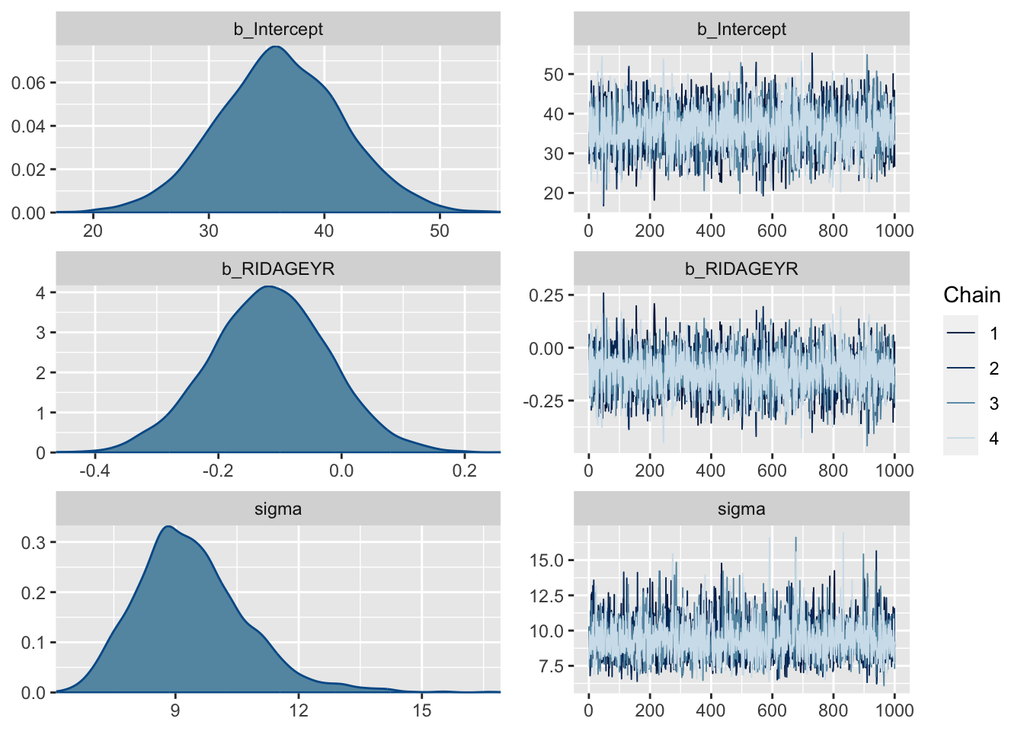

```r
plot(mcmc1)
```

The plots on the right side are the trace plots. We want to see something that represents a fuzzy caterpillar; this means that the generated draws have low serial correlation and that the sample space is explored many times. All three of our trace plots for this model fit the criteria. We can also do `summary(mcmc1)` and look at the values in the `Rhat` column; a value of 1 means our Markov chains have converged sufficiently, which is what we are looking for.

Now, let’s examine some models that fail MCMC diagnostics. Let’s run the same model as the previous example, but set the `iter` parameter to equal 50 (`brms` defaults this parameter to 2000).

```r
mcmc2 <- brm(formula = BMXBMI ~ RIDAGEYR,
             data    = nhanes1518_sample,
             seed    = 123,
             iter    = 50)
```

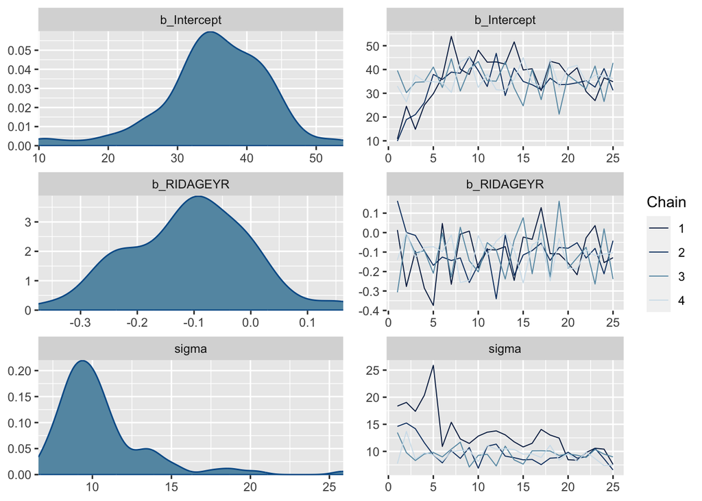

```r
plot(mcmc2)
```

Here, we see our trace plots look vastly different than the ones in the `iter = 2000` example. With plots like this, we can infer that the generated draws have high serial correlations and that the chains are failing to explore the sample space as frequently. This means that the effective size of our sample is too small; we can fix this issue by increasing the number of iterations (in this case, changing the `iter` parameter when fitting our model).

For this next model, we will use the same structure as the previous two models, except we will set the `iter` parameter to 400 and the `warmup` to 10 (the `warmup` parameter defaults to `iter/2`).

```r
mcmc3 <- brm(formula = BMXBMI ~ RIDAGEYR,
             data    = nhanes1518_sample,
             seed    = 123,
             iter    = 400,
             warmup  = 10)
```

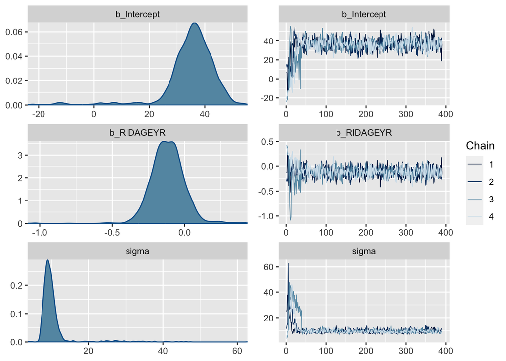

```r
plot(mcmc3)
```

Here, we see that the first portions of the trace plots look very different than the rest; this means our chains are eventually converging to the target distribution (as we get to the ‘fuzzy caterpillar’ portion), but our initial distributions are largely different than the target. We can fix this by increasing the `warmup` parameter, which discards a number of the initial observations.

### Autocorrelation

Trace plots allow us to examine the extent to which serial correlation exists among the draws from our model. We can look at this serial correlation more specifically by plotting the **autocorrelation function (ACF)** of our model.

Let’s plot the autocorrelation for `mcmc1`, the model that we just showed passes MCMC diagnostics. We can use the `mcmc_acf` function of the `bayesplot` package to do so, using the `pars` argument to specify which ACFs we want to see. Recall that an assumption for Bayesian linear regression is the presence of no autocorrelation; thus, we want the ACFs to quickly approach zero.

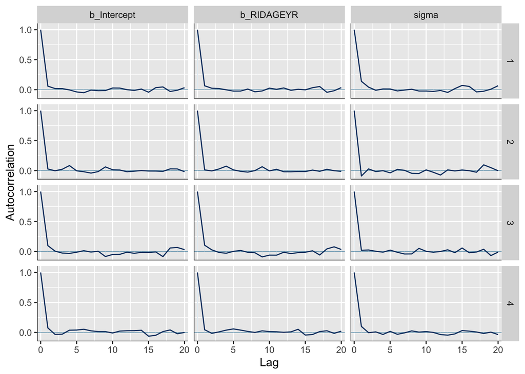

```r
mcmc_acf(mcmc1, pars = c("b_Intercept", "b_RIDAGEYR", "sigma"))
```

The ACFs for this model all quickly approach zero, meaning this is a valid model in terms of the no autocorrelation assumption.

Let’s compare these plots to those for the `mcmc3` model, which we just showed fails MCMC diagnostics.

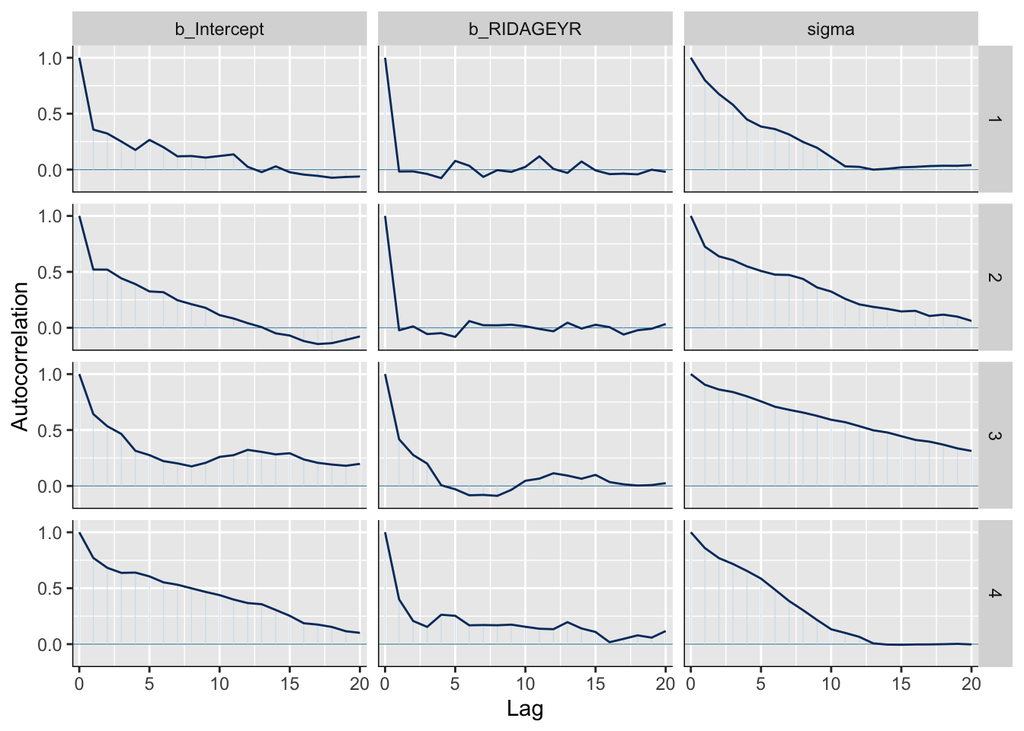

```r
mcmc_acf(mcmc3, pars = c("b_Intercept", "b_RIDAGEYR", "sigma"))
```

These plots take much longer to reach zero, indicating a high degree of serial correlation. We would likely want to refit this model.

### Effective Sample Size

Autocorrelation is closely related to another indicator used in model evaluation: the **effective sample size**. This metric, often notated as $n_{eff}$, estimates the total number of independent draws made from sampling the posterior distribution. Autocorrelation, of course, means that some sequential draws will not be independent. Thus, $n_{eff}$ is usually smaller than the overall sample size $N$.

We can examine effective sample size using the `neff_ratio` and `mcmc_neff` functions from the `bayesplot` package. `neff_ratio` calculates the ratio $\frac{n_{eff}}{N}$ for each parameter specified in the `pars` argument. `mcmc_neff` then takes a vector of these ratios and plots them. Let’s continue to use `mcmc1`, our diagnostic-passing model, and plot its effective sample sizes. We add `theme_minimal` to make the plot easier to read.

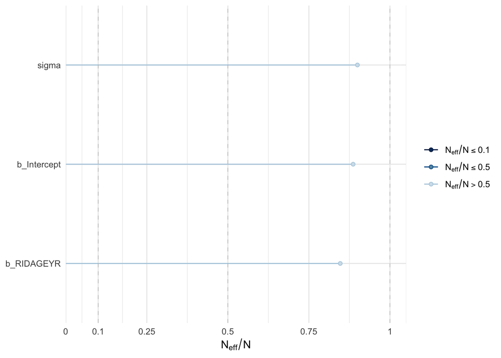

```r
neff_mcmc1 <- neff_ratio(mcmc1, pars = c("b_Intercept", "b_RIDAGEYR", "sigma"))
mcmc_neff(neff_mcmc1) + theme_minimal()
```

This plot shows that the effective sample sizes for the parameters of this model are all close to the overall sample sizes. We want to see ratios closer to 1 (indicated by the lightest blue lines), as these indicate the lowest levels of autocorrelation.

Let’s compare these results to those for `mcmc3`, one of our diagnostic-failing models.

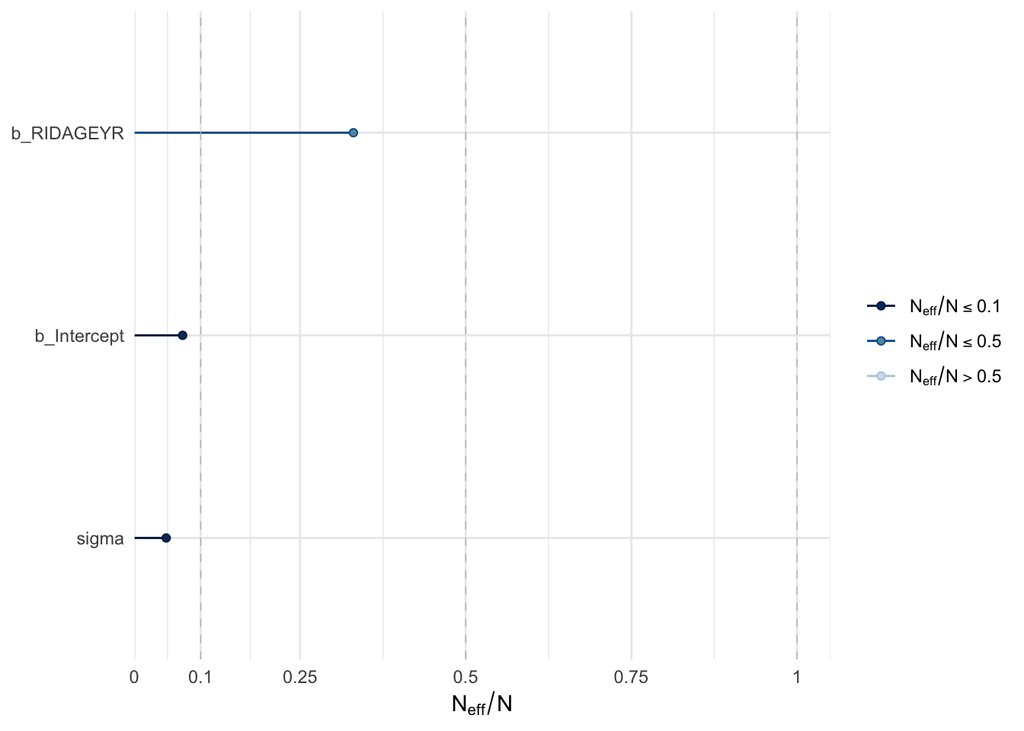

```r
neff_mcmc3 <- neff_ratio(mcmc3, pars = c("b_Intercept", "b_RIDAGEYR", "sigma"))
mcmc_neff(neff_mcmc3) + theme_minimal()
```

As we can see, the effective sample size ratios are much lower for this model, as indicated by darker blue lines. This means there are very little amounts of independent draws from the posterior distributions, indicating high levels of autocorrelation. As concluded earlier, we would want to refit this model.

## Model Comparison

Suppose we have multiple Bayesian linear regression models, and we desire to know which one is “better”. To accomplish this, we can do **model comparison** to determine which of our models minimizes prediction error.

### Widely Applicable Information Criterion (WAIC)

One metric we can use to compare Bayesian models is the **Widely Applicable Information Criterion (WAIC)**, which is an extension of the AIC metric. This statistic is a measurement of prediction error, and therefore we want to choose the model with the smallest WAIC.

Let’s compare the three models we just used to evaluate MCMC diagnostics. We can visualize their WAIC values, which are calculated using the `waic()` method in the `brms` package.

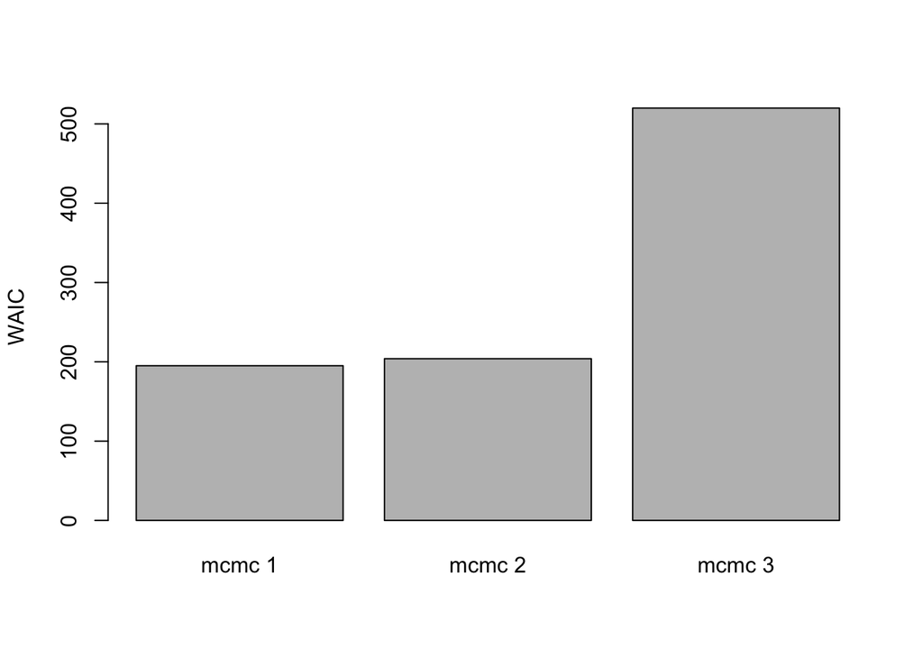

```r
waic1 <- waic(mcmc1)$waic
waic2 <- waic(mcmc2)$waic
waic3 <- waic(mcmc3)$waic
wx <- c(waic1, waic2, waic3)
barplot(wx, ylab = "WAIC", names.arg=paste("mcmc", 1:3))
```

We see that the WAIC for mcmc1 is the lowest. This makes intuitive sense, as this was the model that passed MCMC diagnostics. If we were comparing these three models, we would proceed with `mcmc1`.

We can also use WAIC to determine what are the best priors to select for our data. Let’s take a look at the first five models we fitted in this module, using the `nhanes1518_sample` dataset. Here’s a reminder of their prior distributions and their posterior statistics:

[output not shown]

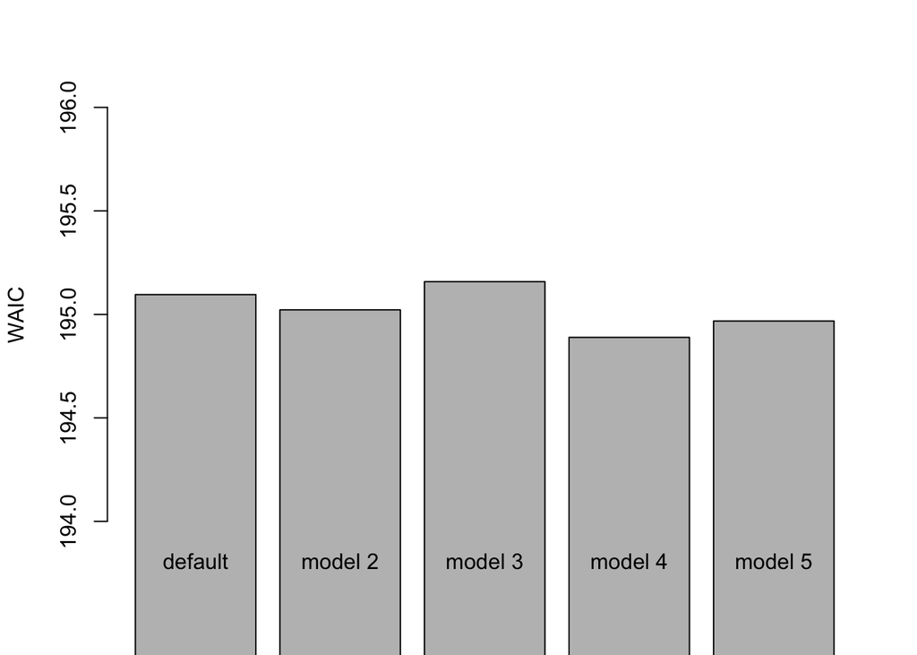

```r
waic_default <- waic(default_prior)$waic
waic_mod2 <- waic(model2)$waic
waic_mod3 <- waic(model3)$waic
waic_mod4 <- waic(model4)$waic
waic_mod5 <- waic(model5)$waic
wy <- c(waic_default, waic_mod2, waic_mod3, waic_mod4, waic_mod5)
barplot(wy, ylab = "WAIC", ylim = c(194, 196),
        names.arg = c("default", paste("model", 2:5)))
```

Although all of the models have very similar WAIC scores, model 4 (which uses a $StudentT(3, 0, 1)$ prior for $\beta_{Age}$) slightly edges out the others. We would proceed with model 4. This makes sense as, since our sample size is very small, it is more fitting to use a student-t distribution than a normal distribution for our prior on $\beta$.

## References

https://www.statlect.com/fundamentals-of-statistics/Markov-Chain-Monte-Carlo-diagnostics https://bookdown.org/ajkurz/Statistical_Rethinking_recoded/markov-chain-monte-carlo.html https://tem11010.github.io/regression_brms/ https://cran.r-project.org/web/packages/bayesplot/vignettes/visual-mcmc-diagnostics.html https://www.r-bloggers.com/2019/11/creating-and-using-a-simple-bayesian-linear-model-in-brms-and-r/ https://mc-stan.org/docs/2_21/functions-reference/inverse-gamma-distribution.html https://solomonkurz.netlify.app/post/2019-07-13-would-you-like-all-your-posteriors-in-one-plot/ https://rstudio-pubs-static.s3.amazonaws.com/157909_f020eeb816364e18a75a3d866f3464e6.html https://michael-franke.github.io/intro-data-analysis/setting-priors.html https://www.rensvandeschoot.com/tutorials/r-linear-regression-bayesian-using-brms/ https://statswithr.github.io/book/introduction-to-bayesian-regression.html#sec:Bayes-multiple-regression https://rpubs.com/katzkagaya/460937 https://gregorygundersen.com/blog/2020/02/04/bayesian-linear-regression/